# Multi-level categorical model

The categorical (cat) model adds item classes to the spatial model:

- distance to the last item (`rho_delta`),
- direction relative to the last move (`rho_psi`),
- absolute direction (`fourier_coef`),
- a class-transition matrix (`b_v`) sets how likely the next item is to be the same class as the last (“sticking”) or a different one.

The multi-level version gives each person their own parameter values (`u_*`) around the condition values, with between-person SDs (`sigma_u_*`).

We simulate six people with known parameters, fit the model, and check it recovers them.

Code: `cat.R`.

```r
# import packages and load our functions
source("../../../../functions/set_up_FoMo.R")
```

```
[1] "set_up_FoMo.R: random seed set to 65 (FOMO_SEED)"
```

```r
# sampler settings (the same in every example; set FOMO_EXAMPLE_ITER for a quick run)
n_iter <- as.integer(Sys.getenv("FOMO_EXAMPLE_ITER", "300"))  # warmup and sampling iterations per chain
n_post_draws <- 50   # posterior draws for posterior predictive simulation
```

## 1 The transition matrix and the papers’ parameters

The single-level cat example shows how `b_v` relates to the papers’ class weight $b_a$ and stick/switch rate $b_s$: with two classes they are the same model. The multi-level models differ even then:

- each row’s log-odds get their own per-person random effect, independently;
- on the papers’ scale, that ties the between-person spreads of $b_a$ and $b_s$ together.

## 2 Simulate

Six people, $K = 2$ conditions, 10 trials per person and condition, on an 8 $\times$ 8 grid with a quarter of cells empty and two item classes. The conditions differ in every parameter:

- Condition *one* sticks with class 1 (rows 0.85/0.15 and 0.45/0.55: $b_a \approx 0.77$, $b_s \approx 0.97$), has weaker distance attraction (0.75), turns back ($-1$) and prefers the four cardinal directions;
- Condition *two* sticks with class 2 (rows 0.5/0.5 and 0.2/0.8: $b_a \approx -0.69$, $b_s \approx 0.69$), has stronger distance attraction (1.5), carries on (1) and prefers moving right.

Each trial’s first selection has no previous item, so it is weighted by class only, using the stationary distribution of each person’s transition matrix. Each person’s values vary around the condition values: the simulation draws each between-person SD from an exponential with rate `sd_lambda` (a larger rate means less spread between people), then each person’s values.

```r
spec <- list(
  K = 2,
  nrow = 8, ncol = 8,
  prop_missing = 0.25,
  v_type = "cat",
  n_classes = 2)

stim <- generate_stim(spec, n_trials = 10, n_people = 6)
```

```r
simparams_cat <- list(
  b_v_pr = list(matrix(c(0.85, 0.15,
                         0.45, 0.55),
                       nrow = spec$n_classes),
                matrix(c(0.50, 0.50,
                         0.20, 0.80),
                       nrow = spec$n_classes)))

simparams_spa <- list(
  rho_delta_mu = c(0.75, 1.50),
  rho_psi_mu = c(-1, 1),
  # absolute direction, Fourier-124 ({cos, sin} per harmonic): condition
  # one prefers the four cardinal directions (h4), two rightwards (h1)
  #                       h1: a, b   h2: a, b   h4: a, b
  fourier_coef_mu = rbind(c(0,   0,     0, 0,     0.8, 0),
                          c(1.5, 0,     0, 0,     0,   0)))

# random effects: each SD is drawn from exponential(sd_lambda)
simparams_sd <- list(
  sd_lambda = list(
    b_v = 2,
    rho_delta = c(3, 3),
    rho_psi = c(10, 10),
    fourier_coef = c(4, 4, 4)))

simparams <- c(simparams_sd, simparams_spa, simparams_cat)

sl_sim <- prep_stan_list(stim, simparams)

sim <- sim_fomo(sl_sim, iter = 1, chains = 1)

found <- extract_pred(sim, stim)
```

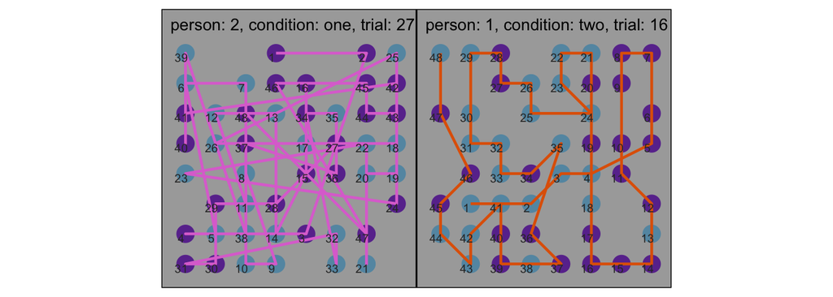

Figure 1: One simulated trial from each condition: items (coloured by class) and selection order.

```r
plot_trial(found, stim)
```

We should expect to see a difference in the run statistics between the two conditions:

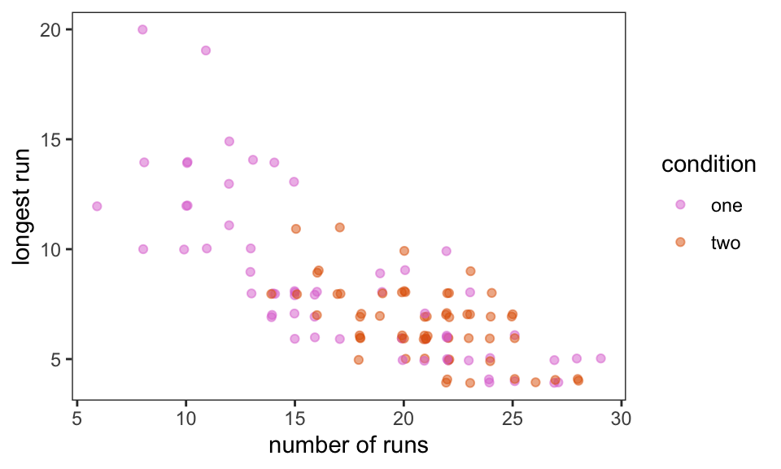

Figure 2: Runs of same-class selections per trial. Stickier behaviour gives fewer, longer runs.

```r
plot_runs(compute_runs(found))
```

Compute trial stats for comparing against the fitted model’s posterior predictions. With several people they are averaged to one row per person and condition, as single trials are noisy.

```r
trial_stats <- compute_trial_stats(found)

head(trial_stats)
```

```
# A tibble: 6 × 8
  condition person n_found best_r mean_itd   pao n_runs max_run_length
  <fct>      <int>   <dbl>  <dbl>    <dbl> <dbl>  <dbl>          <dbl>
1 one            1      48  0.279    0.387 138.    24.9            5.6
2 one            2      48  0.280    0.401 145.    14.9            9.8
3 one            3      48  0.413    0.270  64.2   13.5            9.5
4 one            4      48  0.260    0.377 127.    10.2           13
5 one            5      48  0.387    0.299  81.8   22.3            5.6
6 one            6      48  0.449    0.280  70.5   17.2            7.3
```

We also keep each person’s simulated values, to check the per-person estimates against later, and look at their transition probabilities:

```r
# each person's simulated values
post <- extract_post(sim, found)
groundtruth <- groundtruth_from_sim(simparams, post)
```

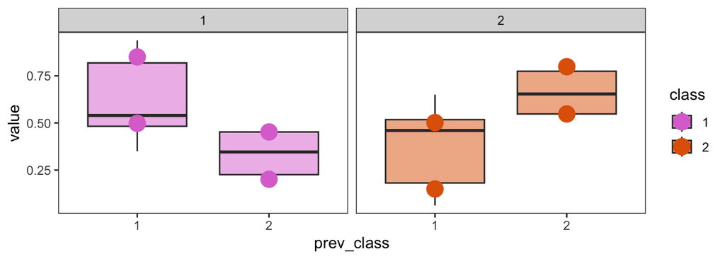

Figure 3: Simulated class-transition probabilities: spread across people (boxes) and condition values (points).

```r
ggplot(post$u$cat, aes(prev_class, value, fill = class)) +
  theme_fomo() +
  geom_boxplot(alpha = 0.5) +
  geom_point(data = post$cat, aes(colour = class), size = 5) +
  facet_wrap(~class)
```

## 3 Fit

We now fit the multi-level categorical version of FoMo to our simulated data. Four chains of 500 warmup and 500 sampling iterations.

*Note*: by default some per-person effects are centred (`centred_params`, see `prep_stan_list()`): distance and the class transitions. With only a few trials per person that gives a funnel and many divergent transitions, so here none are centred (`centred_params = "none"`). We checked this on data simulated as on this page (six people, 10 trials per person and condition), with two seeds, each dataset fitted both ways (4 chains of 500 warmup and 500 sampling iterations; recovery counts every simulation value, per-person ones included):

| Seed | Centring | Divergent transitions | Largest R-hat | Smallest bulk ESS | Recovery | Time (min) |
| --- | --- | --- | --- | --- | --- | --- |
| 65 | default | 29 | 1.014 | 206 | 236 of 240 | 18.5 |
| 65 | none | 0 | 1.011 | 605 | 237 of 240 | 32.8 |
| 101 | default | 101 | 1.030 | 113 | 235 of 240 | 10.8 |
| 101 | none | 2 | 1.012 | 374 | 233 of 240 | 15.7 |

With the default centring, the divergences and the worst R-hat and ESS all come from the between-person SDs of the class transitions (`sigma_u_v`). Without centring, there are none or a few, and every parameter mixes better. Centring suits effects that each person’s data pin down well, which takes more data per person than this: on the real datasets (20-40 trials per person) the default works well. Even without centring, a few divergent transitions can happen with this little data per person.

```r
sl <- prep_stan_list(stim, found = found,
                     centred_params = "none",
                     save_selections = TRUE)
```

```r
# a fixed seed, so the chains are the same on every run
fit <- fit_fomo(sl, iter = n_iter, chains = 4, seed = FOMO_SEED)
```

## 4 Diagnostics

Posterior medians and 97% HPDIs, the values the data were simulated from (`true`, and whether each is `inside` its HPDI), and convergence (R-hat, ESS), for the fixed effects and the between-person SDs (`sigma_u_*`). Each person’s values (`u_*`) are summarised in one row per parameter. About one in 33 simulation values should fall outside its HPDI by chance; with six people the SDs are hard to pin down. R-hat above 1.01, or a bulk or tail ESS in the low hundreds, means the chains haven’t mixed well enough to trust the tails of the posterior. The summary’s last line names the worst parameter (random effects included); the table colours R-hat and ESS green (good), orange (acceptable) or red (bad).

```r
# estimates and convergence, and parameter recovery: are the values used
# to simulate the data inside the posterior's 97% HPDIs?
fomo_summary(fit, sim, random_effects = TRUE, cond_labels = levels(stim$condition))
```

**Population-level parameters (median and 97% HPDI)**

| parameter | condition | component | lower | median | upper | true | inside | rhat | ess_bulk | ess_tail |
| --- | --- | --- | --- | --- | --- | --- | --- | --- | --- | --- |
| rho_delta | one |  | 0.33 | 0.62 | 0.92 | 0.74 | TRUE | 1.01 | 695 | 1049 |
| rho_delta | two |  | 0.82 | 1.47 | 2.16 | 1.51 | TRUE | 1.00 | 1003 | 1120 |
| rho_psi | one |  | -1.36 | -0.97 | -0.57 | -1.01 | TRUE | 1.00 | 1317 | 1126 |
| rho_psi | two |  | 0.64 | 0.95 | 1.25 | 1.00 | TRUE | 1.00 | 3181 | 1472 |
| fourier_coef | one | h1 cos | -0.06 | 0.04 | 0.14 | 0.02 | TRUE | 1.00 | 2250 | 1314 |
| fourier_coef | two | h1 cos | 0.75 | 1.62 | 2.22 | 1.51 | TRUE | 1.00 | 1165 | 1076 |
| fourier_coef | one | h1 sin | -0.34 | 0.05 | 0.42 | 0.01 | TRUE | 1.00 | 1022 | 1103 |
| fourier_coef | two | h1 sin | -0.17 | -0.01 | 0.17 | 0.00 | TRUE | 1.00 | 1679 | 1024 |
| fourier_coef | one | h2 cos | -0.18 | -0.01 | 0.18 | 0.00 | TRUE | 1.00 | 1351 | 1582 |
| fourier_coef | two | h2 cos | -0.13 | -0.01 | 0.11 | -0.01 | TRUE | 1.00 | 1598 | 1101 |
| fourier_coef | one | h2 sin | -0.54 | 0.14 | 0.75 | 0.00 | TRUE | 1.00 | 1065 | 1355 |
| fourier_coef | two | h2 sin | -0.28 | -0.02 | 0.30 | -0.01 | TRUE | 1.00 | 1518 | 1280 |
| fourier_coef | one | h4 cos | 0.52 | 0.97 | 1.34 | 0.80 | TRUE | 1.00 | 1067 | 1044 |
| fourier_coef | two | h4 cos | 0.14 | 0.47 | 0.77 | 0.00 | FALSE | 1.00 | 1095 | 1172 |
| fourier_coef | one | h4 sin | -0.62 | -0.29 | 0.06 | 0.00 | TRUE | 1.00 | 1367 | 1587 |
| fourier_coef | two | h4 sin | -0.22 | -0.05 | 0.11 | -0.01 | TRUE | 1.00 | 2418 | 1294 |
| b_v_logodds | one | 1,1 | 0.05 | 1.30 | 2.65 | 1.74 | TRUE | 1.00 | 1201 | 1097 |
| b_v_logodds | two | 1,1 | -0.45 | -0.01 | 0.46 | -0.01 | TRUE | 1.00 | 1391 | 1138 |
| b_v_logodds | one | 2,1 | -0.43 | -0.23 | -0.02 | -0.19 | TRUE | 1.00 | 2571 | 1308 |
| b_v_logodds | two | 2,1 | -1.58 | -1.31 | -1.05 | -1.38 | TRUE | 1.00 | 1840 | 1216 |
| sigma_u_v | one | 1,1 | 0.61 | 1.23 | 2.51 | 1.08 | TRUE | 1.00 | 1136 | 1249 |
| sigma_u_v | two | 1,1 | 0.03 | 0.35 | 0.89 | 0.43 | TRUE | 1.00 | 719 | 764 |
| sigma_u_v | one | 2,1 | 0.00 | 0.08 | 0.34 | 0.00 | TRUE | 1.01 | 812 | 1036 |
| sigma_u_v | two | 2,1 | 0.00 | 0.13 | 0.46 | 0.15 | TRUE | 1.00 | 818 | 1062 |
| sigma_u_delta | one |  | 0.14 | 0.28 | 0.57 | 0.27 | TRUE | 1.00 | 1098 | 1346 |
| sigma_u_delta | two |  | 0.48 | 0.81 | 1.38 | 0.84 | TRUE | 1.00 | 1641 | 1572 |
| sigma_u_psi | one |  | 0.00 | 0.31 | 0.73 | 0.23 | TRUE | 1.00 | 536 | 435 |
| sigma_u_psi | two |  | 0.00 | 0.10 | 0.43 | 0.17 | TRUE | 1.00 | 1341 | 1128 |
| sigma_u_fourier_coef | one | h1 cos | 0.00 | 0.04 | 0.15 | 0.01 | TRUE | 1.00 | 1185 | 1118 |
| sigma_u_fourier_coef | two | h1 cos | 0.34 | 0.72 | 1.44 | 0.52 | TRUE | 1.00 | 1145 | 1131 |
| sigma_u_fourier_coef | one | h1 sin | 0.18 | 0.38 | 0.78 | 0.31 | TRUE | 1.00 | 841 | 1092 |
| sigma_u_fourier_coef | two | h1 sin | 0.00 | 0.10 | 0.35 | 0.12 | TRUE | 1.00 | 609 | 1028 |
| sigma_u_fourier_coef | one | h2 cos | 0.06 | 0.16 | 0.37 | 0.15 | TRUE | 1.00 | 867 | 988 |
| sigma_u_fourier_coef | two | h2 cos | 0.00 | 0.06 | 0.22 | 0.08 | TRUE | 1.00 | 741 | 1118 |
| sigma_u_fourier_coef | one | h2 sin | 0.56 | 0.92 | 1.52 | 0.92 | TRUE | 1.00 | 1155 | 1107 |
| sigma_u_fourier_coef | two | h2 sin | 0.08 | 0.24 | 0.53 | 0.16 | TRUE | 1.00 | 1302 | 1353 |
| sigma_u_fourier_coef | one | h4 cos | 0.20 | 0.40 | 0.75 | 0.58 | TRUE | 1.00 | 1211 | 1381 |
| sigma_u_fourier_coef | two | h4 cos | 0.16 | 0.31 | 0.58 | 0.46 | TRUE | 1.00 | 1066 | 998 |
| sigma_u_fourier_coef | one | h4 sin | 0.21 | 0.39 | 0.69 | 0.55 | TRUE | 1.00 | 1357 | 1663 |
| sigma_u_fourier_coef | two | h4 sin | 0.00 | 0.05 | 0.22 | 0.12 | TRUE | 1.00 | 1243 | 1202 |
| b_v | one | 1,1 | 0.53 | 0.79 | 0.95 | 0.85 | TRUE | 1.00 | 1201 | 1097 |
| b_v | two | 1,1 | 0.39 | 0.50 | 0.61 | 0.50 | TRUE | 1.00 | 1391 | 1138 |
| b_v | one | 2,1 | 0.39 | 0.44 | 0.50 | 0.45 | TRUE | 1.00 | 2571 | 1308 |
| b_v | two | 2,1 | 0.17 | 0.21 | 0.26 | 0.20 | TRUE | 1.00 | 1840 | 1216 |
| b_v | one | 1,2 | 0.05 | 0.21 | 0.47 | 0.15 | TRUE | 1.00 | 1201 | 1097 |
| b_v | two | 1,2 | 0.39 | 0.50 | 0.61 | 0.50 | TRUE | 1.00 | 1391 | 1138 |
| b_v | one | 2,2 | 0.50 | 0.56 | 0.61 | 0.55 | TRUE | 1.00 | 2571 | 1308 |
| b_v | two | 2,2 | 0.74 | 0.79 | 0.83 | 0.80 | TRUE | 1.00 | 1840 | 1216 |

**Per-person parameters (one row per parameter)**

| parameter | values | inside | max_rhat | min_ess_bulk | min_ess_tail |
| --- | --- | --- | --- | --- | --- |
| u_logit_v | 24 | 24 | 1.01 | 1408 | 1225 |
| u_delta | 12 | 11 | 1.00 | 1480 | 1383 |
| u_psi | 12 | 12 | 1.01 | 1267 | 956 |
| u_fourier_coef | 72 | 71 | 1.01 | 1151 | 1283 |
| u_v | 48 | 48 | 1.01 | 1408 | 1225 |
| u_first_v | 24 | 24 | 1.01 | 1459 | 1511 |

Recovery: 237 of 240 (99%) simulation values inside the 97% HPDI; about 97% expected by chance.

Convergence (all parameters): largest R-hat 1.007 (u_fourier_coef[1,2,1]); smallest bulk ESS 536 (sigma_u_psi[1]), tail ESS 435 (sigma_u_psi[1]); 0 divergent transitions.

Rank plots of the five worst-mixing parameters, judged by R-hat and ESS together. Each histogram shows where one chain’s draws rank among all the draws: if the chains have mixed well, every chain’s histogram is roughly flat and they overlap.

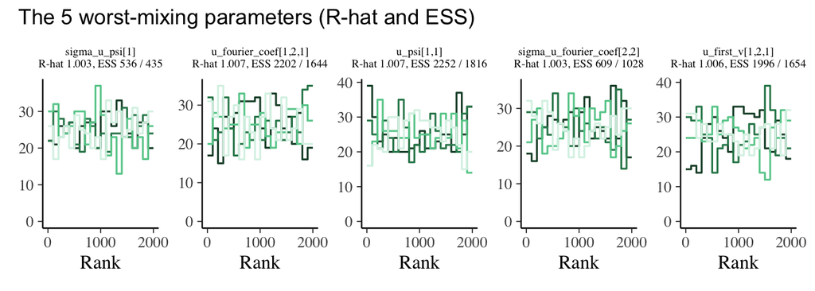

Figure 4: Rank plots of the five worst-mixing parameters, coloured green (good), orange (acceptable) or red (bad) by their R-hat and ESS.

```r
plot_post_traces(fit)
```

`log_lik` is one value per trial, so loo leaves out a whole trial at a time. A Pareto k above 0.7 marks a trial the fit leans on heavily, whose loo estimate is unreliable. `check_high_pareto_k()` lists those trials, worst first, with the person each belongs to (`z`).

```r
loo_result <- fit$loo()
loo_result
```

```
Computed from 2000 by 120 log-likelihood matrix.

         Estimate    SE
elpd_loo  -8761.0 327.8
p_loo        85.3   3.5
looic     17522.0 655.6
------
MCSE of elpd_loo is 0.3.
MCSE and ESS estimates assume MCMC draws (r_eff in [0.8, 1.2]).

All Pareto k estimates are good (k < 0.7).
See help('pareto-k-diagnostic') for details.
```

```r
# the trials with a high Pareto k, worst first
check_high_pareto_k(loo_result, sl)
```

```
# A tibble: 0 × 3
# ℹ 3 variables: trial_idx <int>, z <int>, k <dbl>
```

## 5 Posterior

Where a posterior sits well inside its prior band, the data rather than the prior set the estimate. A posterior pressed against the edge of its band means the prior is doing some of the work.

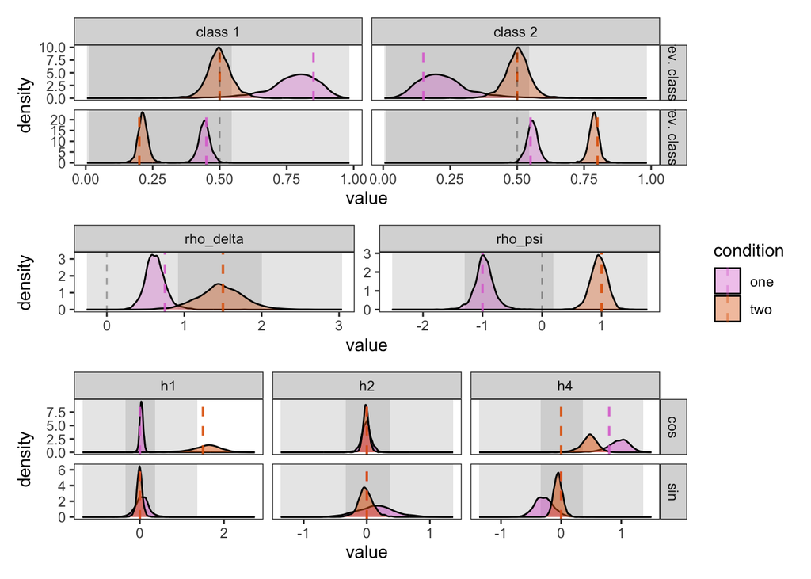

Figure 5: Posterior densities by condition. Grey bands: prior HPDIs; dashed lines: simulation values.

```r
post <- extract_post(fit, found, stim)
plot_post(post, groundtruth = groundtruth)
```

Per-person estimates are pulled towards the condition value (shrinkage), most for people whose own data say least. So a person’s interval can miss an extreme simulation value even when the condition values are recovered.

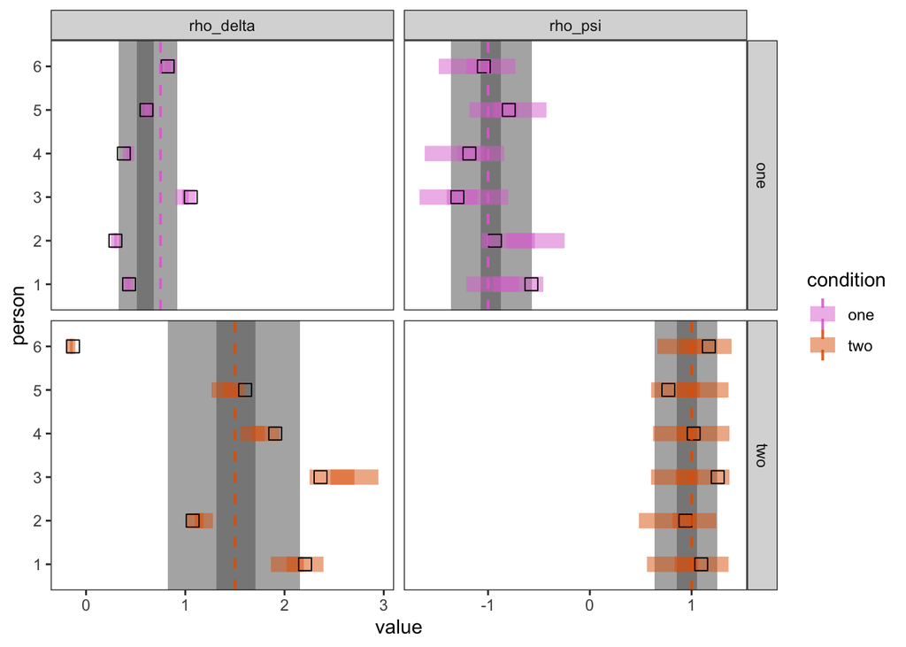

Figure 6: Each person’s $\rho_\delta$ and $\rho_\psi$: posterior intervals, simulation values (squares) and condition-level HPDIs (shaded).

```r
plot_post_per_person_spatial(post, groundtruth)
```

- Deterministic accuracy: how often the item the model judges most likely is the one selected.
- Probability of the chosen item: the probability the model gave the item that was selected, averaged over selections; it credits the model for being nearly right, not only for top picks.
- Chance (1 / items left) rises through a trial as fewer items remain.
- The nearest-neighbour baseline always picks the closest remaining item, so the gap above it is what the model adds to proximity alone.

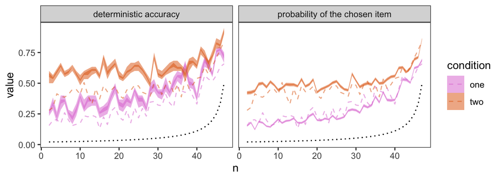

Figure 7: Accuracy of the model’s predictions at each selection, with chance and nearest-neighbour baselines.

```r
plot_post_accuracy(post$acc, stim, found)
```

## 6 Posterior predictive check

None of the trial statistics below is a model parameter, so reproducing them tests whether the fitted model captures aspects of the behaviour it was not fitted to directly. The model doesn’t predict when a trial stops, so each simulated trial keeps as many selections as the data have.

```r
sim_post <- sim_fomo(sl, fit, iter = n_post_draws)

# the model doesn't predict when a trial stops: keep as many simulated
# selections per trial as the data have
extract_pred(sim_post, stim) |>
  semi_join(found, by = c("trial", "n")) -> found_post
```

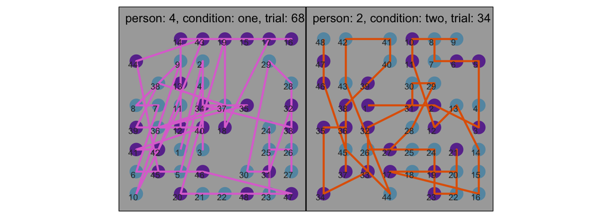

Figure 8: Trials simulated from the fitted model.

```r
plot_trial(found_post, stim)
```

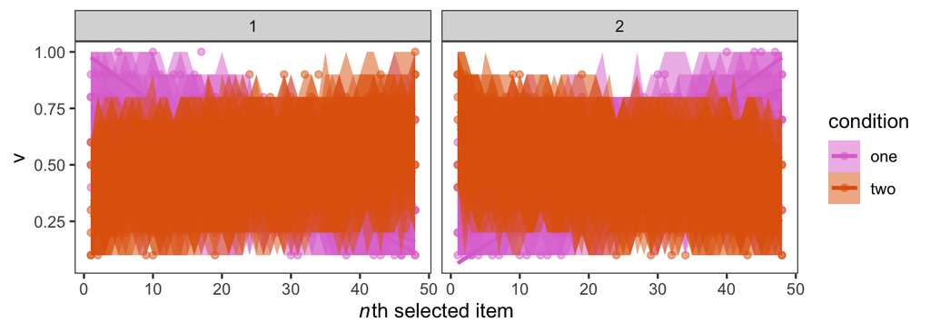

Figure 9: Proportion of each class selected at each point in a trial: fitted data vs data simulated from the posterior.

```r
plot_features(found, feature = "v", sim = found_post)
```

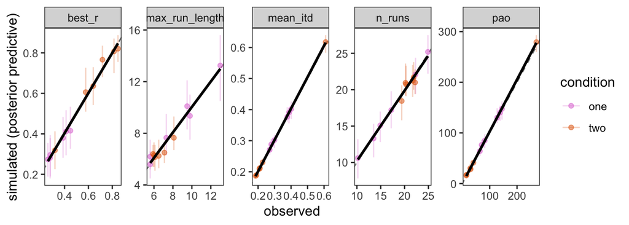

Figure 10: Trial statistics per person for the fitted data (x) and data simulated from the posterior (y). Points near the diagonal mean the model reproduces them.

```r
# compare per-trial foraging statistics between the training data and data
# simulated from the fitted posterior
sim_stats <- compute_trial_stats(found_post)
plot_trial_stats(trial_stats, sim_stats)
```